# Lab 5 LHC

```python
# import library
import pickle
import numpy as np
from matplotlib import pyplot as plt
from scipy.stats import poisson
from scipy.stats import norm

# open the file of interest, and use pickle loading
infile = open ("qcd_100000_pt_250_500.pkl",'rb')
new_dict = pickle.load(infile)
infile = open ("higgs_100000_pt_250_500.pkl",'rb')
higg = pickle.load(infile)
# list all keys of the files
print(new_dict.keys())
print(higg.keys())
plt.rcParams["figure.figsize"] = (15,12)
```

```
Index(['pt', 'eta', 'phi', 'mass', 'ee2', 'ee3', 'd2', 'angularity', 't1',
       't2', 't3', 't21', 't32', 'KtDeltaR'],
      dtype='object')
Index(['pt', 'eta', 'phi', 'mass', 'ee2', 'ee3', 'd2', 'angularity', 't1',
       't2', 't3', 't21', 't32', 'KtDeltaR'],
      dtype='object')
```

```python
# Print two variables, mass and d2, of the first 10 jets
for i in range(10):
 print(new_dict['mass'][i],new_dict['d2'][i])
```

```
125.29872026896659 3.304886302915122
88.0470543065784 2.4390891450626166
85.79417445424248 4.118371457491606
42.94732814665354 8.038338215316234
59.54222652643443 6.353842223846714
52.25202892050295 35.22466496007628
87.72005721179889 3.8934825497044394
59.648628855244354 8.789222507192793
74.23631116158323 3.2765540773471997
41.90450338556174 26.87568501726949
```

To begin, The training data has 14 parameters, some more useful here than others.

pt is our transverse momentum, mass is the jet mass. These two will most likely be the most useful.

We have angularity,eta,phi, and ktdeltaR. All of these are spacial measurements usful in reconstructing the path of the jet and particles.

The t parameters seem to be related to a kind of jet shape that is usful at distinguishing between multiple differebt kidns of particles

ee2,ee3, and d2 are related to energy correlation and are usful when deeling with hadronic decays and Z boson detection

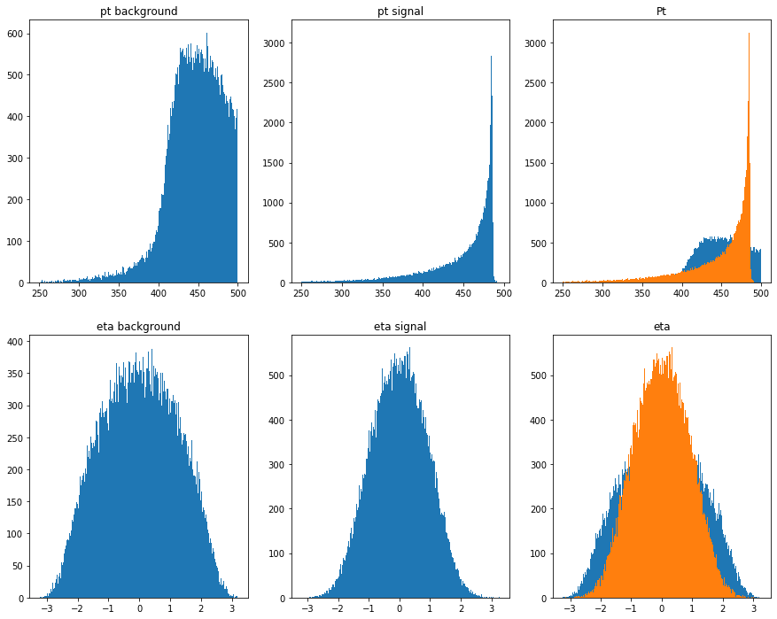

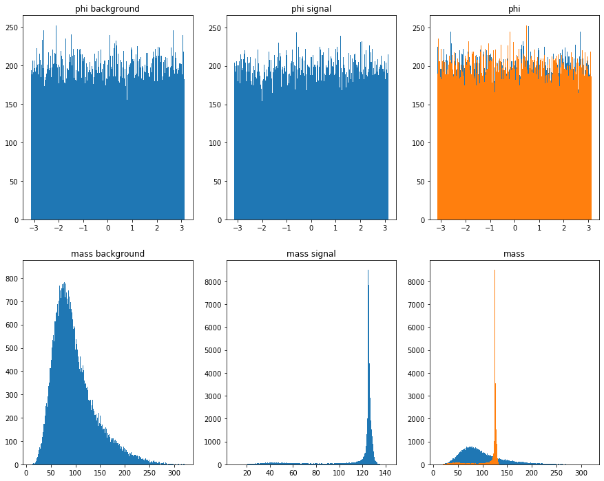

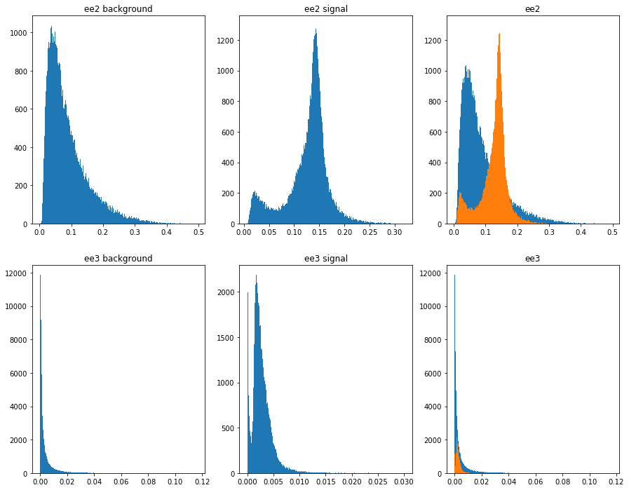

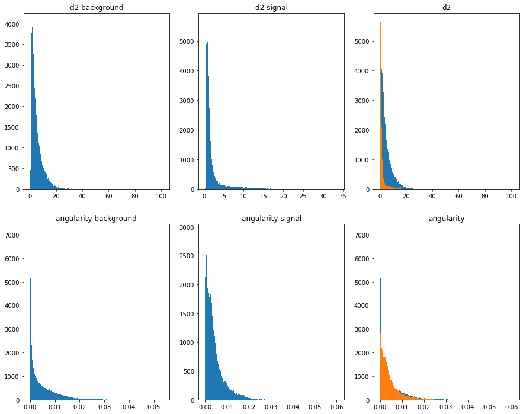

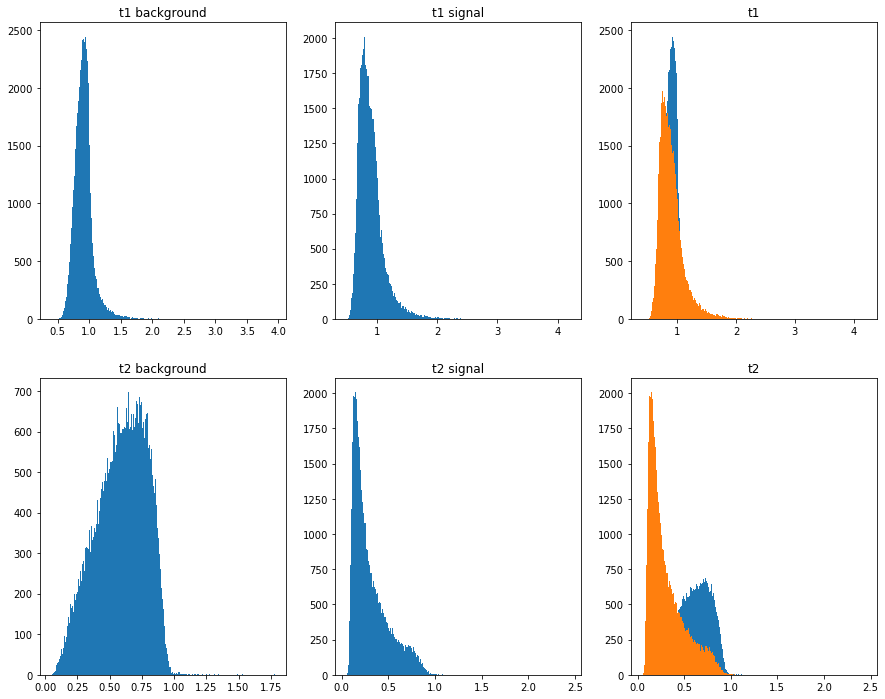

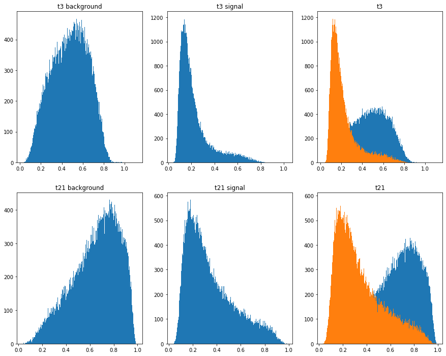

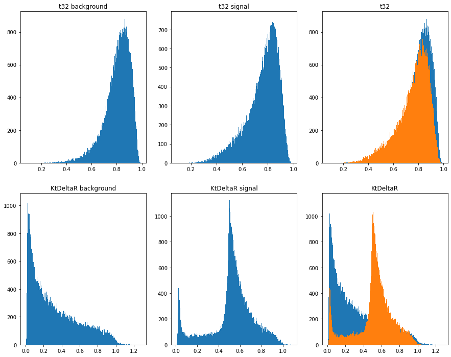

```python
plt.subplot(2, 3, 1)
plt.hist(new_dict['pt'],500)
plt.title('pt background')
plt.subplot(2, 3, 2)
plt.hist(higg['pt'],500)
plt.title('pt signal')
plt.subplot(2, 3, 3)
plt.hist(new_dict['pt'],500)
plt.hist(higg['pt'],500)
plt.title('Pt')
plt.subplot(2, 3, 4)
plt.hist(new_dict['eta'],500)
plt.title('eta background')
plt.subplot(2, 3, 5)
plt.hist(higg['eta'],500)
plt.title('eta signal')
plt.subplot(2, 3, 6)
plt.hist(new_dict['eta'],500)
plt.hist(higg['eta'],500)
plt.title('eta')
plt.show()

plt.subplot(2, 3, 1)
plt.hist(new_dict['phi'],500)
plt.title('phi background')
plt.subplot(2, 3, 2)
plt.hist(higg['phi'],500)
plt.title('phi signal')
plt.subplot(2, 3, 3)
plt.hist(new_dict['phi'],500)
plt.hist(higg['phi'],500)
plt.title('phi')
plt.subplot(2, 3, 4)
plt.hist(new_dict['mass'],500)
plt.title('mass background')
plt.subplot(2, 3, 5)
plt.hist(higg['mass'],500)
plt.title('mass signal')
plt.subplot(2, 3, 6)
plt.hist(new_dict['mass'],500)
plt.hist(higg['mass'],500)
plt.title('mass')
plt.show()


plt.subplot(2, 3, 1)
plt.hist(new_dict['ee2'],500)
plt.title('ee2 background')
plt.subplot(2, 3, 2)
plt.hist(higg['ee2'],500)
plt.title('ee2 signal')
plt.subplot(2, 3, 3)
plt.hist(new_dict['ee2'],500)
plt.hist(higg['ee2'],500)
plt.title('ee2')
plt.subplot(2, 3, 4)
plt.hist(new_dict['ee3'],500)
plt.title('ee3 background')
plt.subplot(2, 3, 5)
plt.hist(higg['ee3'],500)
plt.title('ee3 signal')
plt.subplot(2, 3, 6)
plt.hist(new_dict['ee3'],500)
plt.hist(higg['ee3'],500)
plt.title('ee3')
plt.show()

plt.subplot(2, 3, 1)
plt.hist(new_dict['d2'],500)
plt.title('d2 background')
plt.subplot(2, 3, 2)
plt.hist(higg['d2'],500)
plt.title('d2 signal')
plt.subplot(2, 3, 3)
plt.hist(new_dict['d2'],500)
plt.hist(higg['d2'],500)
plt.title('d2')
plt.subplot(2, 3, 4)
plt.hist(new_dict['angularity'],500)
plt.title('angularity background')
plt.subplot(2, 3, 5)
plt.hist(higg['angularity'],500)
plt.title('angularity signal')
plt.subplot(2, 3, 6)
plt.hist(new_dict['angularity'],500)
plt.hist(higg['angularity'],500)
plt.title('angularity')
plt.show()

plt.subplot(2, 3, 1)
plt.hist(new_dict['t1'],500)
plt.title('t1 background')
plt.subplot(2, 3, 2)
plt.hist(higg['t1'],500)
plt.title('t1 signal')
plt.subplot(2, 3, 3)
plt.hist(new_dict['t1'],500)
plt.hist(higg['t1'],500)
plt.title('t1')
plt.subplot(2, 3, 4)
plt.hist(new_dict['t2'],500)
plt.title('t2 background')
plt.subplot(2, 3, 5)
plt.hist(higg['t2'],500)
plt.title('t2 signal')
plt.subplot(2, 3, 6)
plt.hist(new_dict['t2'],500)
plt.hist(higg['t2'],500)
plt.title('t2')
plt.show()

plt.subplot(2, 3, 1)
plt.hist(new_dict['t3'],500)
plt.title('t3 background')
plt.subplot(2, 3, 2)
plt.hist(higg['t3'],500)
plt.title('t3 signal')
plt.subplot(2, 3, 3)
plt.hist(new_dict['t3'],500)
plt.hist(higg['t3'],500)
plt.title('t3')
plt.subplot(2, 3, 4)
plt.hist(new_dict['t21'],500)
plt.title('t21 background')
plt.subplot(2, 3, 5)
plt.hist(higg['t21'],500)
plt.title('t21 signal')
plt.subplot(2, 3, 6)
plt.hist(new_dict['t21'],500)
plt.hist(higg['t21'],500)
plt.title('t21')
plt.show()

plt.subplot(2, 3, 1)
plt.hist(new_dict['t32'],500)
plt.title('t32 background')
plt.subplot(2, 3, 2)
plt.hist(higg['t32'],500)
plt.title('t32 signal')
plt.subplot(2, 3, 3)
plt.hist(new_dict['t32'],500)
plt.hist(higg['t32'],500)
plt.title('t32')
plt.subplot(2, 3, 4)
plt.hist(new_dict['KtDeltaR'],500)
plt.title('KtDeltaR background')
plt.subplot(2, 3, 5)
plt.hist(higg['KtDeltaR'],500)
plt.title('KtDeltaR signal')
plt.subplot(2, 3, 6)
plt.hist(new_dict['KtDeltaR'],500)
plt.hist(higg['KtDeltaR'],500)
plt.title('KtDeltaR')
plt.show()
```

1.Do all features provide discrimination power between signal and background?

Some parameters discriminate between signal and background very dramaticly others are almost indistinguishable and therefor not very usful to us.

Some notable parameters include:

Mass and pt, both of which have a very distinct spike in the signal data that looks nothing like the background.

ee2,t2,t3,t21,ktdeltaR all have fairly differentiable signals but not to the degree that mass and pt are differentiable. These ar characterized more by a shift in the weight of the distrabution more than any change in amplitude.

eta,phi,d2,ee3,angularity,t1, and t32 all have signals that look a bit too much like the background distrabution to be very useful, some signals (like ee3) dont even make it out of the background distrabutions amplitude or range.

2.Are there correlations among these features?

The few obvous corrilations we can see are mostly in the shape of the distrabution. pt and mass are spikes in the mid-higher ranges, the tx and txx signals are all psuedo-exponential curves leaning left (or right for t32). ee3, d2, and angularity are all very near zero.

1. below are computations for the discovery senstivity for a mass and pt measurement.

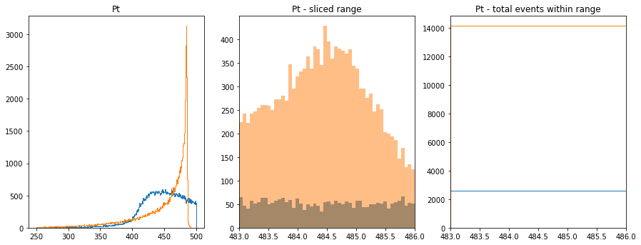

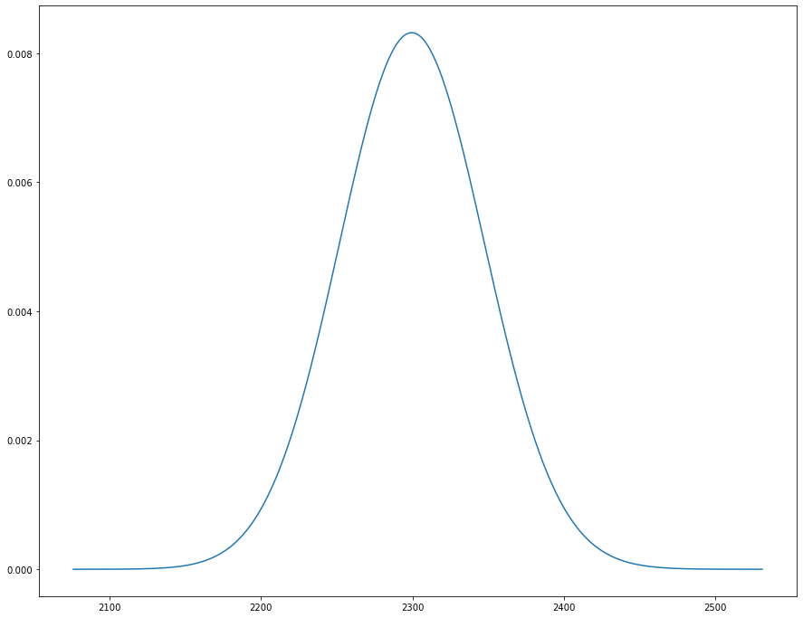

```
5 sigma detection boundry = 2544.0
```

```python
plt.subplot(2, 3, 1)
plt.hist(new_dict['pt'],500,histtype = 'step')
plt.hist(higg['pt'],500,histtype = 'step')
plt.title('Pt')
plt.subplot(2, 3, 2)
plt.hist(new_dict['pt'],50,alpha=0.8,range = (483,486))
plt.hist(higg['pt'],50,alpha=0.5,range = (483,486))
plt.title('Pt - sliced range')
plt.xlim(483,486)
plt.subplot(2, 3, 3)
plt.hist(new_dict['pt'],1,histtype = 'step',range = (483,486))
plt.hist(higg['pt'],1,histtype = 'step',range = (483,486))
plt.title('Pt - total events within range')
plt.xlim(483,486)
plt.show()
fig, ax = plt.subplots(1,1)
mu = 2300
x = np.arange(poisson.ppf(0.000001, mu),poisson.ppf(0.999999, mu))
ax.plot(x, poisson.pmf(x, mu))
plt.show()
sig = poisson.ppf((norm.cdf(5)),mu)
print("5 sigma detection boundry =",sig)
```

Below I did the same thing as above, but with mass. Finding a 5 sigma boundry of about total 6900 events within the range 120-132.

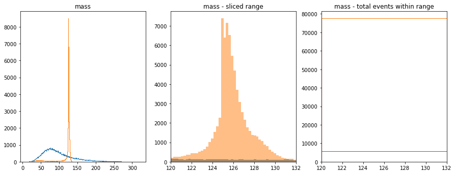

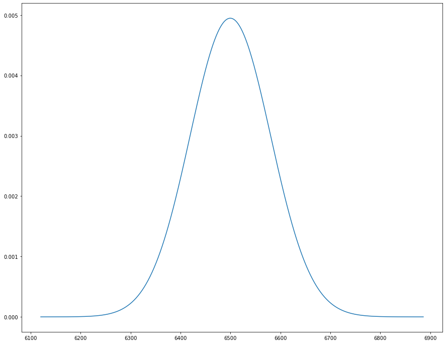

```
5 sigma detection boundry = 6907.0
```

```python
plt.subplot(2, 3, 1)
plt.hist(new_dict['mass'],500,histtype = 'step')
plt.hist(higg['mass'],500,histtype = 'step')
plt.title('mass')
plt.subplot(2, 3, 2)
plt.hist(new_dict['mass'],50,alpha=0.8,range = (120,132))
plt.hist(higg['mass'],50,alpha=0.5,range = (120,132))
plt.title('mass - sliced range')
plt.xlim(120,132)
plt.subplot(2, 3, 3)
plt.hist(new_dict['mass'],1,histtype = 'step',range = (120,132))
plt.hist(higg['mass'],1,histtype = 'step',range = (120,132))
plt.title('mass - total events within range')
plt.xlim(120,132)
plt.show()
fig, ax = plt.subplots(1,1)
mu = 6500
x = np.arange(poisson.ppf(0.000001, mu),poisson.ppf(0.999999, mu))
ax.plot(x, poisson.pmf(x, mu))
plt.show()
sig = poisson.ppf((norm.cdf(5)),mu)
print("5 sigma detection boundry =",sig)
```

4.Develop a plan to optimize the discovery sensitivity by applying selections to these features. In the future I will use more parameters and tighter range selction to further optomize the descovery sensitivity. But, some of that has already been done here when choosing the specfic x-ranges to measure in.